# Getting started with functional statistical testing

```r
library(funStatTest)
```

The `funStatTest` package implements various statistics for two sample comparison testing regarding functional data.

## Authorship and license

This package is developed by:

- Zaineb Smida ([ORCID](https://orcid.org/0000-0002-9974-299X))
- Ghislain Durif ([link](https://gdurif.perso.math.cnrs.fr/)|[ORCID](https://orcid.org/0000-0003-2567-1401))
- Lionel Cucala ([link](https://imag.umontpellier.fr/~cucala/))

It implements statistics (and related experiments) introduced and used in [1].

## Data simulation

Here are some functions used to simulate clustered trajectories of functional data based on the Karhunen-Loève decomposition.

The functional data simulation process is described in [1] (section 3.1).

### Simulate a single trajectory

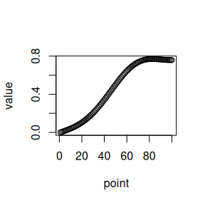

```r
simu_vec <- simul_traj(100)
plot(simu_vec, xlab = "point", ylab = "value")
```

### Simulate trajectories from two samples diverging by a delta

```r
simu_data <- simul_data(
    n_point = 100, n_obs1 = 50, n_obs2 = 75, c_val = 10,
    delta_shape = "constant", distrib = "normal"
)
str(simu_data)
```

```
#> List of 5
#>  $ mat_sample1: num [1:100, 1:50] 10 10.1 10.2 10.3 10.4 ...
#>  $ mat_sample2: num [1:100, 1:75] 0 0.00241 0.00497 0.00775 0.01071 ...
#>  $ c_val      : num 10
#>  $ distrib    : chr "normal"
#>  $ delta_shape: chr "constant"
```

### Graphical representation of simulated data

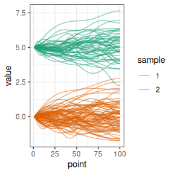

```r
# constant delta
simu_data <- simul_data(
    n_point = 100, n_obs1 = 50, n_obs2 = 75, c_val = 5,
    delta_shape = "constant", distrib = "normal"
)
plot_simu(simu_data)
```

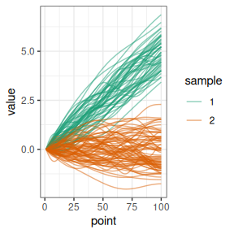

```r
# linear delta
simu_data <- simul_data(
    n_point = 100, n_obs1 = 50, n_obs2 = 75, c_val = 5,
    delta_shape = "linear", distrib = "normal"
)
plot_simu(simu_data)
```

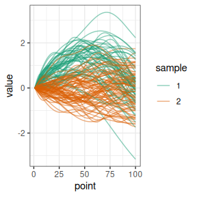

```r
# quadratic delta
simu_data <- simul_data(
    n_point = 100, n_obs1 = 50, n_obs2 = 75, c_val = 5,
    delta_shape = "quadratic", distrib = "normal"
)
plot_simu(simu_data)
```

## Statistics

### MO median statistic

The $MO$ median statistic [1] is implemented in the `stat_mo()` function.

```r
simu_data <- simul_data(
    n_point = 100, n_obs1 = 50, n_obs2 = 75, c_val = 10,
    delta_shape = "constant", distrib = "normal"
)

MatX <- simu_data$mat_sample1
MatY <- simu_data$mat_sample2

stat_mo(MatX, MatY)
```

```
#> [1] 0.9988008
```

### MED median statistic

The $MED$ median statistic [1] is implemented in the `stat_med()` function.

```r
simu_data <- simul_data(
    n_point = 100, n_obs1 = 50, n_obs2 = 75, c_val = 10,
    delta_shape = "constant", distrib = "normal"
)

MatX <- simu_data$mat_sample1
MatY <- simu_data$mat_sample2

stat_med(MatX, MatY)
```

```
#> [1] 0.9993601
```

### WMW statistic

The Wilcoxon-Mann-Whitney statistic [2] (noted $WMW$ in [1]) is implemented in the `stat_wmw()` function.

```r
simu_data <- simul_data(
    n_point = 100, n_obs1 = 50, n_obs2 = 75, c_val = 10,
    delta_shape = "constant", distrib = "normal"
)

MatX <- simu_data$mat_sample1
MatY <- simu_data$mat_sample2

stat_wmw(MatX, MatY)
```

```
#> [1] 0.9984562
```

### HKR statistics

The Horváth-Kokoszka-Reeder statistics [3] (noted $HKR1$ and $HKR2$ in [1]) are implemented in the `stat_hkr()` function.

```r
simu_data <- simul_data(
    n_point = 100, n_obs1 = 50, n_obs2 = 75, c_val = 10,
    delta_shape = "constant", distrib = "normal"
)

MatX <- simu_data$mat_sample1
MatY <- simu_data$mat_sample2

stat_hkr(MatX, MatY)
```

```
#> $T1
#> [1] 56962058560
#>
#> $T2
#> [1] 297023.2
#>
#> $eigenval
#>  [1] 3.664005e+01 5.308985e+00 1.522118e+00 6.759658e-01 2.275435e-01
#>  [6] 1.705847e-01 9.892918e-02 6.026029e-02 3.071646e-02 1.788522e-02
#> [11] 1.102164e-02 9.424057e-03 6.172824e-03 5.108395e-03 2.334137e-03
#> [16] 1.450027e-03 3.118851e-04 6.975138e-05 1.716764e-09
```

### CFF statistic

The Cuevas-Febrero-Fraiman statistic [4] (noted $CFF$ in [1]) is implemented in the `stat_cff()` function.

```r
simu_data <- simul_data(
    n_point = 100, n_obs1 = 50, n_obs2 = 75, c_val = 10,
    delta_shape = "constant", distrib = "normal"
)

MatX <- simu_data$mat_sample1
MatY <- simu_data$mat_sample2

stat_cff(MatX, MatY)
```

```
#> [1] 511045.7
```

### Compute multiple statistics

The function `comp_stat()` allows to compute multiple statistics defined above in a single call on the same data.

```r
simu_data <- simul_data(
    n_point = 100, n_obs1 = 50, n_obs2 = 75, c_val = 10,
    delta_shape = "constant", distrib = "normal"
)

MatX <- simu_data$mat_sample1
MatY <- simu_data$mat_sample2

res <- comp_stat(MatX, MatY, stat = c("mo", "med", "wmw", "hkr", "cff"))
res
```

```
#> $mo
#> [1] 0.9989056
#>
#> $med
#> [1] 0.9992861
#>
#> $wmw
#> [1] 0.9985099
#>
#> $hkr
#>            [,1]
#> T1 5.132184e+10
#> T2 3.018523e+05
#>
#> $cff
#> [1] 511580.1
```

## Permutation-based computation of p-values

P-values associated to the different statistics defined above can be computed with the permutation-based method as follow:

```r
# simulate small data for the example
simu_data <- simul_data(
    n_point = 20, n_obs1 = 4, n_obs2 = 5, c_val = 10,
    delta_shape = "constant", distrib = "normal"
)

MatX <- simu_data$mat_sample1
MatY <- simu_data$mat_sample2
res <- permut_pval(
    MatX, MatY, n_perm = 100, stat = c("mo", "med", "wmw", "hkr", "cff"),
    verbose = TRUE)
res
```

```
#> $mo
#> [1] 0.01980198
#>
#> $med
#> [1] 0.01980198
#>
#> $wmw
#> [1] 0.01980198
#>
#> $hkr
#>         T1         T2
#> 0.01980198 0.01980198
#>
#> $cff
#> [1] 0.01980198
```

> :warning: computing p-values based on permutations may take some time (for large data or when using a large number of simulations. :warning:

## Simulation-based power analysis

We use our simulation scheme with permutation-based p-values computation to run a power analysis to evaluate the different statistics.

```r
# simulate a few small data for the example
res <- power_exp(
    n_simu = 20, alpha = 0.05, n_perm = 100,
    stat = c("mo", "med", "wmw", "hkr", "cff"),
    n_point = 25, n_obs1 = 4, n_obs2 = 5, c_val = 10, delta_shape = "constant",
    distrib = "normal", max_iter = 10000, verbose = FALSE
)
res$power_res
```

```
#> $mo
#> [1] 1
#>
#> $med
#> [1] 1
#>
#> $wmw
#> [1] 1
#>
#> $hkr
#> T1 T2
#>  1  1
#>
#> $cff
#> [1] 1
```

## References

1.

**Smida**, **Z**, **Cucala**, **L**, **Gannoun**, **A**, and **Durif**, **G** 2022 A median test for functional data. *Journal of Nonparametric Statistics*, 34(2): 520–553. DOI: https://doi.org/10.1080/10485252.2022.2064997

2.

**Chakraborty**, **A** and **Chaudhuri**, **P** 2015 A Wilcoxon–Mann–Whitney-type test for infinite-dimensional data. *Biometrika*, 102(1): 239–246. DOI: https://doi.org/10.1093/biomet/asu072

3.

**Horváth**, **L**, **Kokoszka**, **P**, and **Reeder**, **R** 2013 Estimation of the mean of functional time series and a two-sample problem. *Journal of the Royal Statistical Society. Series B (Statistical Methodology)*, 75(1): 103–122. DOI: https://doi.org/10.1111/j.1467-9868.2012.01032.x

4.

**Cuevas**, **A**, **Febrero**, **M**, and **Fraiman**, **R** 2004 An anova test for functional data. *Computational Statistics & Data Analysis*, 47(1): 111–122. DOI: https://doi.org/10.1016/j.csda.2003.10.021